# EAS648 Lab05

Haolin Li (haolinli@umich.edu)

2023-11-16

# EAS 648 Lab 05: Applied spatial analysis

> **Links:**

> **Course Repository**: https://github.com/HumblePasty/EAS648

> **Lab05 Webpage**: https://humblepasty.github.io/EAS648/Lab/05/

> **Lab05 Repository**: https://github.com/HumblePasty/EAS648/tree/master/Lab/05

> Assignment
> 1. Analyze the Salt Lake City dataset. Fit a model that explains suitability for urban development (provide evidence of goodness of model fit). What characteristics contribute to urban development in Salt Lake? What variable might you add to better explain urban development. (1-2 paragraphs)
> 2. Analyze the database of amenity landscape characteristics using a clustering technique. Choose variables based on a thematic inquiry of your choice. Visualize ad provide qualitative descriptions of the groups that you derive from the clustering techniques. Provide evidence of you characterizations. Provide a map of your cluster analysis. Give an explanation of the spatial distribution of these groups. (1-2 paragraphs)

> Haolin’s Note:

> For this assignment, I’ll complete the tasks in 2 parts:
> - Part I: Analyze the Salt Lake City dataset and Model Fitting
> - Part II: Cluster Analysis of Landscape Characteristics

## Part I: Analyze the Salt Lake City dataset and Model Fitting

### Preparing the Dataset

```r
library(terra)
#first import the land cover/use data
NLCD_2001 <- rast("Lab5prj/NLCD_2001_SL.tif")
NLCD_2004 <- rast("Lab5prj/NLCD_2004_SL.tif")
NLCD_2006 <- rast("Lab5prj/NLCD_2006_SL.tif")
NLCD_2008 <- rast("Lab5prj/NLCD_2008_SL.tif")
NLCD_2011 <- rast("Lab5prj/NLCD_2011_SL.tif")
NLCD_2013 <- rast("Lab5prj/NLCD_2013_SL.tif")
NLCD_2016 <- rast("Lab5prj/NLCD_2016_SL.tif")
# Distance to parks and protected areas in km (Euclidean) for the study area
Park_dist <- rast("Lab5prj/Parks_dist_SL.tif")
# Road density for a 1 km neighborhood
Rd_dns1km <- rast("Lab5prj/Rd_dns1km_SL.tif")
# Distance to water bodies in km (Euclidean)
WaterDist <- rast("Lab5prj/WaterDist_SL.tif")
# Elevation
DEM <- rast("Lab5prj/DEM_SL.tif")

allrasters <- c(NLCD_2001, NLCD_2004, NLCD_2006, NLCD_2008, NLCD_2011, NLCD_2013, NLCD_2016, Park_dist, Rd_dns1km, WaterDist,DEM)

library(tidyverse)
allrastersSL <- as.data.frame(allrasters, xy=TRUE)
## Here we are filtering out the no data values (stored as 128)
allrastersSL <- allrastersSL %>%
  filter (NLCD_2001_SL != 128)
head(allrastersSL)
```

```
##          x       y NLCD_2001_SL NLCD_2004_SL NLCD_2006_SL NLCD_2008_SL
## 1 -1330860 2102550           11           52           52           95
## 2 -1330830 2102550           11           52           52           95
## 3 -1330800 2102550           11           11           11           11
## 4 -1330770 2102550           11           11           11           11
## 5 -1330740 2102550           11           11           11           11
## 6 -1330710 2102550           11           11           71           71
##   NLCD_2011_SL NLCD_2013_SL NLCD_2016_SL Parks_dist_SL Rd_dns1km_SL
## 1           95           95           95      1358.308            0
## 2           95           95           95      1343.317            0
## 3           95           11           11      1328.834            0
## 4           95           11           11      1314.876            0
## 5           95           11           95      1301.461            0
## 6           71           71           71      1288.255            0
##   WaterDist_SL DEM_SL
## 1     301.4963   1281
## 2     305.9412   1281
## 3     313.2092   1281
## 4     323.1099   1281
## 5     330.0000   1281
## 6     331.3608   1281
```

> Pre-plotting the Data

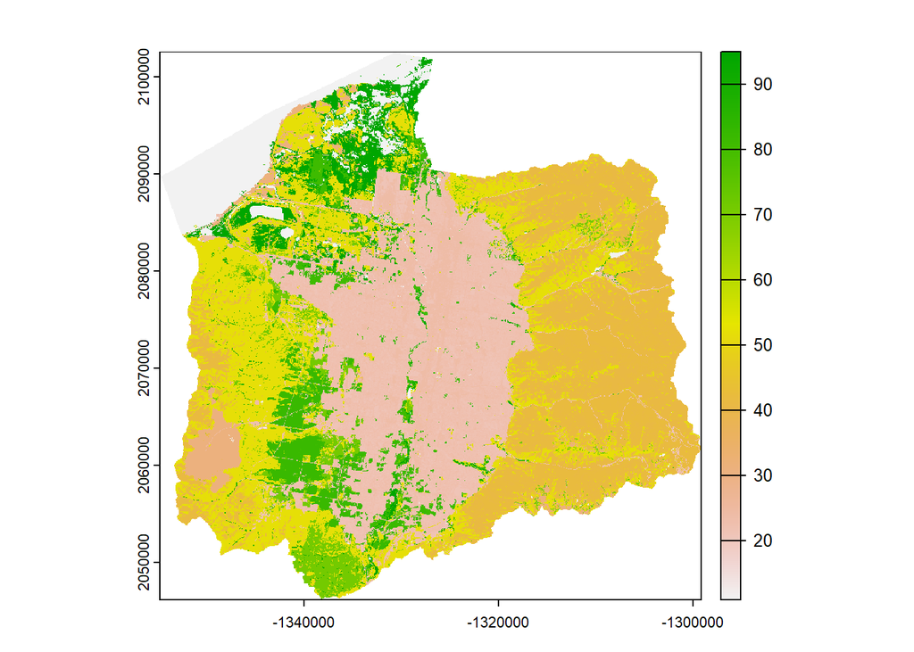

```r
plot(NLCD_2001)
```

### Sampling the Data

```r
library(leaflet)
library(ggplot2)
sampleSLrnd <- spatSample(allrasters, size=100, "random", cells=TRUE, xy=TRUE)
head(sampleSLrnd)
```

```
##      cell        x       y NLCD_2001_SL NLCD_2004_SL NLCD_2006_SL NLCD_2008_SL
## 1 3204425 -1325760 2050800           NA           NA           NA           NA
## 2 3124113 -1340880 2052090           52           52           52           52
## 3 1369006 -1320810 2080470           81           81           81           81
## 4 2396508 -1342470 2063850           52           52           52           52
## 5 2911941 -1302840 2055540           NA           NA           NA           NA
## 6 1818460 -1311750 2073210           42           42           42           42
##   NLCD_2011_SL NLCD_2013_SL NLCD_2016_SL Parks_dist_SL Rd_dns1km_SL
## 1           NA           NA           NA            NA           NA
## 2           52           52           52     18521.180    0.0000000
## 3           81           81           81      3113.069    0.3654729
## 4           52           52           52     12721.485    0.1037649
## 5           NA           NA           NA            NA           NA
## 6           42           42           42         0.000    0.0000000
##   WaterDist_SL DEM_SL
## 1           NA     NA
## 2     530.7542   1815
## 3    1772.2866   1400
## 4     391.1521   1580
## 5           NA     NA
## 6     692.6038   2170
```

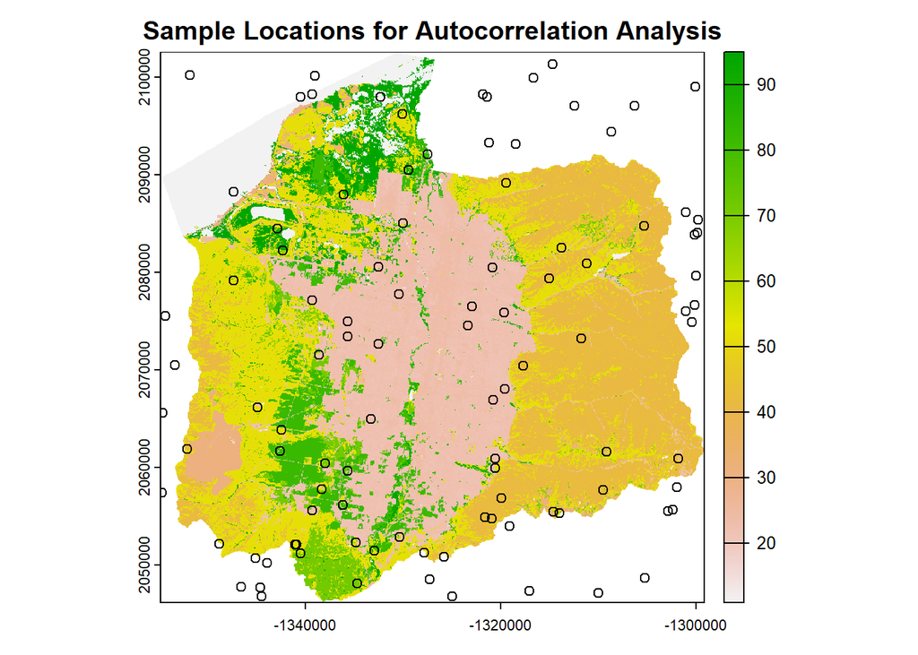

```r
plot(NLCD_2001, main = "Sample Locations for Autocorrelation Analysis")
points(sampleSLrnd$x, sampleSLrnd$y)
```

### Spatial Autocorrelation Analysis (Moran’s I)

```r
# flatten the spatial data to a dataframe that has lat and long
flat_data <- as.data.frame(sampleSLrnd)
flat_data = na.omit(flat_data)
# calculate distances between all the points,
dist_matrix <- as.matrix(dist(cbind(flat_data$x, flat_data$y)))
# and generate a matrix of inverse distance weights.
dist_matix.inv <- 1/dist_matrix
diag(dist_matix.inv) <- 0

library(ape)
# Moran.I(sampleSLrnd$Rd_dns1km_SL, dist_matix.inv)
Moran.I(flat_data$Rd_dns1km_SL, dist_matix.inv)
```

```
## $observed
## [1] 0.1491992
##
## $expected
## [1] -0.01754386
##
## $sd
## [1] 0.03219732
##
## $p.value
## [1] 2.233313e-07
```